# El título de mayor tamaño se escribe con un sharp

Una alternativa al uso de un sharp es con símbolos de igual en la línea inmediata.

# Nuevo título de igual tamaño que con un sharp

## Este es un subtítulo con dos sharps

### Este es un subtítulo con tres sharps

Vamos a trabajar ahora con formatos. La letra negrita se puede escribir con doble estrella o con doble guión bajo: **Este es un texto en negrita** y **este es otro**.

Además, también podemos escribir en cursivas (igualmente conocidas como itálicas). Esto se hace con una sola estrella al inicio y final o con un solo guión bajo al inicio y final: *este es un ejemplo* y *este es otro*.

Incluso, para tachar texto usamos doble virgulilla como en este caso.

Digamos que quiero escribir “x elevado al cuadrado”. Esto lo hago con el símbolo de cuña (es una v invertida): x<sup>2</sup>. Asimismo, para subíndices se hace con virgulilla simple (abriendo y cerrando), como por ejemplo x<sub>2</sub>.

Una de mis funciones favoritas de R es tapply. Su sintaxis es `tapply(columna1,columna2,función)`.

Todos aquí saben que nuestro repositorio se encuentra en https://github.com/scidatmath2020. En particular, el Taller de Introducción a Ciencia de datos lo tenemos [aquí, en este lugar](https://github.com/scidatmath2020/Taller_ICD_Rm).

También podemos hacer listas:

- Esta es una viñeta
- Esta es otra
  - Esta es una subviñeta de la anterior
- Esta ya es la última.

¡También podemos jugar con colores! Y no solo con palabras, sino también con frases completas.

El incrustado de imágenes es realmente muy simple:

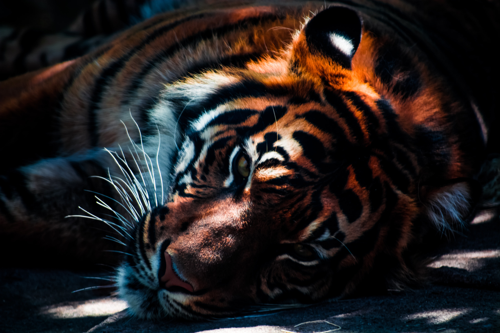

Fuente: Elaboración Propia

# **Un título con colores y negrita**

Tenemos que pagar €300, porque perdimos y 3<1